# 05_10_2020

## The Daily Graph.

```
05/10/2020
```

The table and graphs follow. I didn't accomplish much today or rather I didn't accomplish anything I want to post. I started looking at models a bit on one county to get comfortable with statmodels version of least squares. I selected three different 5 day periods in leon county: first 5, last 5, and middle 5 days. There was of course a major difference between the slopes. However, the thing that hung me up was the intercept. Since at time =0, the number of cases is 1 (or close to it), the log is then 0 so no intercept makes sense. However if one starts later it does not. At any rate, I think there are two possible approaches I can try. Some version of the one I tried -- split the time frame into discrete pieces of equal length and model each segment. I used 5 days simply because Wicklin did, but would try other values. The other thing I think might be interesting is to use a 'running' period. For example using 5 days, the first period would be 0-4, the next 1-5 and so on. I shall keep plugging. I could, by the way, leave out the first five days and use intercepts in all models. Any thoughts are welcome.

Summary Statistics for the selected counties.

[output not shown]

## Today's Graph

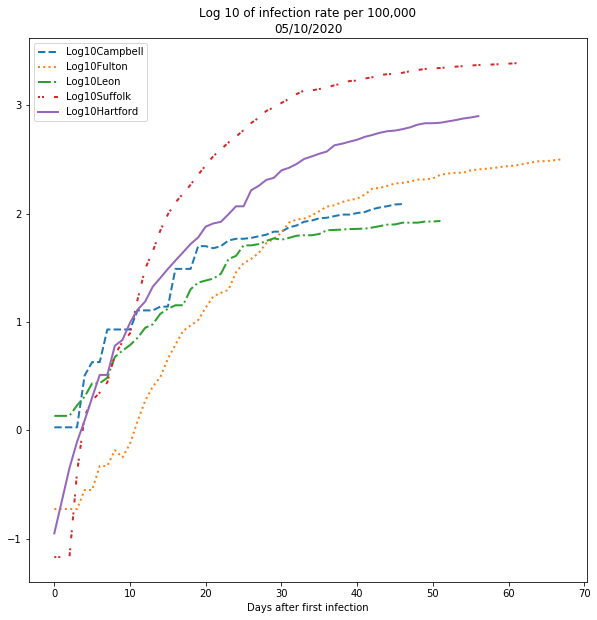